# Hunting for TFs using tradeSeq: incorporating derivative threshold

Koen Van den Berge

1/17/2020

```r
here::set_here()
```

```
## File .here already exists in /Users/koenvandenberge/Dropbox/research/brainStat/hbcRegenGithub/scripts
```

```r
suppressPackageStartupMessages({
  library(slingshot)
  library(tradeSeq)
  library(SingleCellExperiment)
  library(cowplot)
  library(rgl)
  library(clusterExperiment)
  library(RColorBrewer)
  library(aggregation)
  library(ggplot2)
  library(pheatmap)
  library(wesanderson)
  library(UpSetR)
  library(gridExtra)
})
```

# Import data

```r
sds <- readRDS("../data/finalTrajectory/sling.rds")
counts <- readRDS("../data/finalTrajectory/counts_noResp_noMV.rds")
counts <- round(counts)
sce <- readRDS("../data/finalTrajectory/sce_tradeSeq20200904.rds")
load("../data/ALL_TF.Rda")
clDatta <- readRDS("../data/finalTrajectory/dattaCl_noResp_noMV.rds")
```

# Helper functions

```r
source("https://raw.githubusercontent.com/statOmics/tradeSeq/master/R/utils.R")
epsilon <- 1e-6

calculateDerivatives <- function(sce, gene, lineage, epsilon=1e-6, nPoints=100){
  ## gather all required objects
  id <- which(rownames(sce) == gene)
  beta <- matrix(unlist(rowData(sce)$tradeSeq$beta[id,]),ncol=1)
  if(any(is.na(beta))){
    dfsd <- data.frame(der=rep(NA, nPoints), sdDer=rep(NA, nPoints))
    colnames(dfsd) <- c(paste0("der",lineage), paste0("sdDer",lineage))
    return(dfsd)
  }
  Sigma <- rowData(sce)$tradeSeq$Sigma[[id]]
  X <- colData(sce)$tradeSeq$X
  slingshotColData <- colData(sce)$slingshot
  pseudotime <- slingshotColData[,grep(x = colnames(slingshotColData),
                                                            pattern = "pseudotime")]
  dm <- colData(sce)$tradeSeq$dm

  ## calculate lp matrix with finite differencing
  newd1 <- .getPredictRangeDf(dm, lineage, nPoints=nPoints)
  newd2 <- newd1
  newd1[,paste0("t",lineage)] <- newd1[,paste0("t",lineage)] - epsilon
  X0 <- predictGAM(X, newd1, pseudotime)
  newd2[,paste0("t",lineage)] <- newd2[,paste0("t",lineage)] + epsilon
  X1 <- predictGAM(X, newd2, pseudotime)
  Xp <- (X1-X0)/(2*epsilon) ## maps coefficients to (fd approx.) derivatives

  ## calculate first derivative
  df <- Xp%*%beta              ## ith smooth derivative
  df.sd <- rowSums(Xp%*%Sigma*Xp)^.5 ## cheap diag(Xi%*%b$Vp%*%t(Xi))^.5
  dfsd <- data.frame(der=df, sdDer=df.sd)
  colnames(dfsd) <- c(paste0("der",lineage), paste0("sdDer",lineage))
  return(dfsd)
}


calculateDerivativesWithSigma <- function(sce, gene, lineage, epsilon=1e-6, nPoints=100){
  ## gather all required objects
  id <- which(rownames(sce) == gene)
  beta <- matrix(unlist(rowData(sce)$tradeSeq$beta[id,]),ncol=1)
  Sigma <- rowData(sce)$tradeSeq$Sigma[[id]]
  X <- colData(sce)$tradeSeq$X
  slingshotColData <- colData(sce)$slingshot
  pseudotime <- slingshotColData[,grep(x = colnames(slingshotColData),
                                                            pattern = "pseudotime")]
  dm <- colData(sce)$tradeSeq$dm

  ## calculate lp matrix with finite differencing
  newd1 <- .getPredictRangeDf(dm, lineage, nPoints=nPoints)
  newd2 <- newd1
  newd1[,paste0("t",lineage)] <- newd1[,paste0("t",lineage)] - epsilon
  X0 <- predictGAM(X, newd1, pseudotime)
  newd2[,paste0("t",lineage)] <- newd2[,paste0("t",lineage)] + epsilon
  X1 <- predictGAM(X, newd2, pseudotime)
  Xp <- (X1-X0)/(2*epsilon) ## maps coefficients to (fd approx.) derivatives

  ## calculate first derivative
  df <- Xp%*%beta              ## ith smooth derivative
  #df.sd <- rowSums(Xp%*%Sigma*Xp)^.5 ## cheap diag(Xi%*%b$Vp%*%t(Xi))^.5
  sigmaDer <- Xp%*%Sigma%*%t(Xp)
  dfsd <- list(der=df, sdDer=sigmaDer)
  names(dfsd) <- c(paste0("der",lineage), paste0("sdDer",lineage))
  return(dfsd)
}



plotSmoothersWithDerivatives <- function(sce, gene, counts, gridDf, derDf){

  dfAll <- as.data.frame(cbind(gridDf,derDf))

  cowplot::plot_grid(
    #smoothers
    plotSmoothers(sce, gene=gene, counts=counts, lwd=1),
    ggplot(dfAll, aes(x=grid1, y=derDf$der1)) +
      geom_line() +
      geom_line(aes(x=grid1, y=derDf$der1 - 2*derDf$sdDer1), lty=2) +
      geom_line(aes(x=grid1, y=derDf$der1 + 2*derDf$sdDer1), lty=2) +
      geom_hline(yintercept=0, col="red") +
      ggtitle("Neuronal lineage") +
      ylab("First derivative"),
    ggplot(dfAll, aes(x=grid2, y=derDf$der2)) +
      geom_line() +
      geom_line(aes(x=grid2, y=derDf$der2 - 2*derDf$sdDer2), lty=2) +
      geom_line(aes(x=grid2, y=derDf$der2 + 2*derDf$sdDer2), lty=2) +
      geom_hline(yintercept=0, col="red") +
      ggtitle("rHBC lineage") +
      ylab("First derivative"),
    ggplot(dfAll, aes(x=grid3, y=derDf$der3)) +
      geom_line() +
      geom_line(aes(x=grid3, y=derDf$der3 - 2*derDf$sdDer3), lty=2) +
      geom_line(aes(x=grid3, y=derDf$der3 + 2*derDf$sdDer3), lty=2) +
      geom_hline(yintercept=0, col="red") +
      ggtitle("SUS lineage") +
      ylab("First derivative"),
    # test statistics
    ggplot(dfAll, aes(x=grid1, y=derDf$der1/derDf$sdDer1)) +
      geom_line() +
      geom_line(aes(x=grid2, y=derDf$der2/derDf$sdDer2)) +
      geom_line(aes(x=grid3, y=derDf$der3/derDf$sdDer3)) +
      geom_hline(yintercept=0, col="red") +
      ggtitle("Test statistics"),
    nrow=3, ncol=2
  )
}



makeGSEATable <- function(overlapFile, nBP=20){
  overlap <- readLines(overlapFile)
  overlapSets <- overlap[10:30]
  overlapSetsSplit <- sapply(overlapSets, function(x) strsplit(x, split = "\t"))
  gsNames <- unname(unlist(lapply(overlapSetsSplit, "[[", 1)))
  genesInSet <- unname(unlist(lapply(overlapSetsSplit, "[[", 2)))
  genesInOverlap <- unname(unlist(lapply(overlapSetsSplit, "[[", 4)))
  pvalUniqGam <- unname(unlist(lapply(overlapSetsSplit, "[[", 6)))
  qval <- unname(unlist(lapply(overlapSetsSplit, "[[", 7)))
  gsNames <- tolower(gsNames)
  gsNames <- gsub(x = gsNames, pattern = "_", replacement = " ")
  gsNames[-1] <- unname(sapply(gsNames[-1], function(x) substr(x, 4, nchar(x))))
  tab <- data.frame(
    geneSet = gsNames[-1],
    overlap = as.numeric(genesInOverlap[-1]),
    genesInSet = as.numeric(genesInSet[-1]),
    qvalue = qval[-1]
  )
  #library(xtable)
  #print(xtable(tab), type="html")
  return(tab)
}
```

# Estimate first derivatives

```r
tf <- intersect(ALL_TF, rownames(sce))

# derAllTF <- list()
# for(ii in 1:length(tf)){
#   gene <- tf[ii]
#   derGene <- do.call(cbind, sapply(1:3, function(ll){
#     calculateDerivatives(sce=sce,
#                         gene=gene,
#                         lineage=ll,
#                         nPoints=100)
#   }, simplify=FALSE))
#   derAllTF[[ii]] <- derGene
# }
# saveRDS(derAllTF, file="../data/derAllTF_20200916.rds")
derAllTF <- readRDS("../data/derAllTF_20200916.rds")
names(derAllTF) <- tf
```

# Order TFs based on expression peak, require a threshold on derivative to be called significant

A gene’s expression peaks when its first derivative equals zero. Hence, we could use this to order the TFs which have a significant expression peak.

Since the goal of this analysis is ordering of genes, we will ignore multiple testing correction across genes. However, since we want to restrict ourselves to genes that actually do have a significant expression peak, we will do within-gene FWER correction.

```r
nPoints <- 100
dm <- colData(sce)$tradeSeq$dm
grid1 <- tradeSeq:::.getPredictRangeDf(dm = dm,
                                       lineageId = 1,
                                       conditionId = NULL,
                                       nPoints = nPoints)


cp <- c('#1B9E77', '#E6AB02',  '#E7298A', '#66A61E', '#BEAED4' ,'#D95F02',   '#A6761D', '#666666',  '#1F78B4') #Rebecca colors
cl <- factor(colnames(sds@clusterLabels)[apply(sds@clusterLabels,1,which.max)])

colDf <- data.frame(cl=levels(cl),
                    rcCol=cp, #RKC colors
                    trCol=brewer.pal(9,'Set1')) #KS colors


### write a function that creates an Anno object with length as nPoints.
anno <- function(lineage, nPoints, sds, dm, cl, lengthThresh=5){
   cp <- c('#1B9E77', '#E6AB02',  '#E7298A', '#66A61E', '#BEAED4' ,'#D95F02',   '#A6761D', '#666666',  '#1F78B4') #Rebecca colors
  #cl <- factor(colnames(sds@clusterLabels)[apply(sds@clusterLabels,1,which.max)])
  pt <- slingPseudotime(sds)[,lineage]
  #cw <- slingCurveWeights(sds)
  #linID <- apply(cw,1,which.max)
  linID <- apply(dm[,paste0("l",1:3)], 1, which.max)
  pt1 <- pt[linID == lineage]
  cl1 <- droplevels(cl[linID == lineage])
  ## divide pseudotime in nPoint
  #qq <- quantile(pt1, probs = seq(0,1,length=nPoints+1))
  qq <- seq(0, max(pt1), length.out=nPoints+1)
  allCols <- c()
  for(kk in 1:nPoints){
    id <- which(pt1 > qq[kk] & pt1 < qq[kk+1])
    if(length(id) < lengthThresh){
      allCols[kk] <- "white"
      next
    }
    maxCl <- names(sort(table(droplevels(cl1[id])), decreasing=TRUE))[1]
    col <- which(levels(cl) == maxCl)
    allCols[kk] <- cp[col]
  }
  return(allCols)
}

orderPeakGenesThresh <- function(grid1, derivatives, tf, lineage, sce, cl,
                           main=NULL, ablines=NULL, plotHist=TRUE,
                           plotLines = TRUE, plotHeatmap = TRUE,
                           threshold = 0.025, clusteredHeatmap=TRUE,
                           show_rownames = TRUE, show_colnames=FALSE){

  # grid1 is the grid on which the derivatives have been calculated
  # derivatives is a list of first derivatives and their SD
  # tf is a vector of all TF names
  # lineage is the lineage of interest
  # sce are the fitted tradeSeq models
  # cl are the cluster labels

  nPoints <- nrow(grid1)
  # 1. first select genes with a significant first derivative anywhere in the lineage.
  # I do not consider negative first derivatives here since we're focussed on peaks.
  ## a. calculate p-values without threshold => for selecting uniquely peaking genes
  pvalNeurAllNoThresh <- lapply(derivatives, function(x){
    der <- x[,(lineage*2 - 1)]
    derSD <- x[,(lineage*2)]
    testStat <- der / derSD
    # testStat <- (abs(der)-threshold) / derSD
    pvals <- pmin(1,(1-pnorm(testStat)))
    return(pvals)
  })
  pvalNoThresh <- do.call(rbind,pvalNeurAllNoThresh)
  ## b. calculate p-values with threshold.
  resNeurAll <- lapply(derivatives, function(x){
    der <- x[,(lineage*2 - 1)]
    derSD <- x[,(lineage*2)]
    # testStat <- der / derSD
    testStat <- (abs(der)-threshold) / derSD
    pvals <- pmin(1,(1-pnorm(testStat)))
    pvals[der < threshold] <- 1
    return(list(testStat=testStat,
                pvals=pvals))
  })
  pvalNeurAll <- lapply(resNeurAll, function(x) x$pvals)
  testNeurAll <- lapply(resNeurAll, function(x) x$testStat)
  pvalThresh <- do.call(rbind,pvalNeurAll)
  testThresh <- do.call(rbind,testNeurAll)
  maxTestsThresh <- matrixStats::rowMaxs(testThresh)
  # Check significance.
  neurPeakGenes <- tf[unlist(lapply(pvalNeurAll, function(x) any(p.adjust(x, "holm") <= 0.05)))]
  pvalNeurAll <- pvalNeurAll[neurPeakGenes]
  length(neurPeakGenes) / length(tf)


  # 2. then define the most pronounced peak by looking at the maximum test statistic for each gene
  tLin <- grid1[,paste0("t",lineage)]
  tNeur <- tLin[unlist(lapply(pvalNeurAll, which.min))]
  # hist(tNeur)

  # 3. then define where that peak peaks by checking where the first derivative crosses zero the first time AFTER the pseudotime value defined above.
  firstPeak <- c()
  for(ii in 1:length(neurPeakGenes)){
    gene <- neurPeakGenes[ii]
    tMax <- tNeur[ii]
    d1 <- derivatives[[gene]][,paste0("der",lineage)]
    # check where the derivative crosses zero first time AFTER tNeur
    d1 <- d1[grid1[,paste0("t",lineage)] > tMax]
    t1 <- grid1[,paste0("t",lineage)][grid1[,paste0("t",lineage)] > tMax]
    tCrossZero <- t1[which(diff(sign(d1))==-2)]
    if(length(tCrossZero)==0){
      firstPeak[ii] <- NA
      next
    }
    firstPeak[ii] <- min(tCrossZero)
  }
  names(firstPeak) <- neurPeakGenes
  firstPeak[is.na(firstPeak)] <- max(grid1)
  oo <- order(firstPeak, decreasing=FALSE)

  if(plotHist){
    hist(firstPeak, breaks=50, main=paste0("Peak times: ", main),
                    xlim = c(0,max(grid1)))
  }



  ## line plot
  X <- colData(sce)$tradeSeq$X # linear predictor
  slingshotColData <- colData(sce)$slingshot
  pseudotime <- slingshotColData[,grep(x = colnames(slingshotColData),
                                        pattern = "pseudotime")]
  betaMat <- rowData(sce)$tradeSeq$beta[[1]]
  rownames(betaMat) <- rownames(sce)
  Xdf <- predictGAM(lpmatrix = X,
                    df = grid1,
                    pseudotime = pseudotime)

  yhatMat <- matrix(NA, nrow=length(firstPeak), ncol=nPoints)
  rownames(yhatMat) <- names(firstPeak)
  for(ii in 1:length(firstPeak)){
    beta <- betaMat[rownames(yhatMat)[ii],]
    yhat <-  c(exp(t(Xdf %*% t(beta))))
    yhatMat[ii,] <- yhat
  }
  yhatMatScaled <- t(scale(t(yhatMat)))

    if(plotLines){
    pal <- wesanderson::wes_palette("Zissou1", n=length(firstPeak), type="continuous")
  plot(x=grid1[,paste0("t",lineage)], y=seq(min(yhatMatScaled), max(yhatMatScaled), length.out=nPoints), type='n', bty='l',
       ylab="Standardized Expression", xlab="Pseudotime", main=main)
  for(ii in 1:length(firstPeak)){
    lines(x=grid1[,paste0("t",lineage)], y=yhatMatScaled[names(firstPeak)[oo][ii],], col=pal[ii])
  }
  if(!is.null(ablines)) abline(v=ablines, col="black", lwd=3)
  }


  ## heatmap
   if(plotHeatmap){
    annCols <- anno(lineage, nPoints, sds, dm, cl)
    annCols2 <- as.character(colDf$trCol[match(annCols, colDf$rcCol)])
    annCols2[is.na(annCols2)] <- "white"
    dfAnn <- data.frame(cellType=annCols, cellType2=annCols2)
    rownames(dfAnn) <- colnames(yhatMatScaled)
    annColors <- list()
    annColors[[1]] <- as.character(levels(factor(annCols)))
    names(annColors[[1]]) <- levels(factor(annCols))
    annColors[[2]] <- as.character(levels(factor(annCols2)))
    names(annColors[[2]]) <- levels(factor(annCols2))
    names(annColors) <- c("cellType", "cellType2")

    pal <- wesanderson::wes_palette("Zissou1", n=12, type="continuous")
    yhatMatScaledOrdered <- yhatMatScaled[names(firstPeak)[oo],]
    colnames(yhatMatScaledOrdered) <- rownames(dfAnn) <- as.character(1:ncol(yhatMatScaledOrdered))
    pheatmap(yhatMatScaledOrdered, cluster_cols=FALSE, cluster_rows=FALSE,
           border_color=NA, col=pal, main=main, annotation_col=dfAnn,
             annotation_colors = annColors, annotation_names_col = FALSE,
             annotation_legend = FALSE, show_rownames = show_rownames,
           show_colnames = show_colnames)#, colors=cols, breaks=breaks)
    if(clusteredHeatmap){
      pheatmap(yhatMatScaledOrdered, cluster_cols=FALSE, cluster_rows=TRUE,
           border_color=NA, col=pal, main=paste0(main,": Clustered genes"), annotation_col=dfAnn,
             annotation_colors = annColors, annotation_names_col = FALSE,
             annotation_legend = FALSE, show_rownames = show_rownames,
           show_colnames = show_colnames)
    }
  }

  return(list(firstPeak=firstPeak, standExpr=yhatMatScaled,
              yhat=yhatMat,
              pvalNoThresh=pvalNoThresh, pvalThresh=pvalThresh,
              maxTestStats = maxTestsThresh))
}

heatmapScaledAcrossAllLineages <- function(models, genes, sds, nPoints, outFile, g=20,
                                           cl, width=40, height=20){
  ### scaled across all lineages
  yhat <- tradeSeq::predictSmooth(models=models, gene=genes, nPoints=nPoints, tidy=FALSE)
  yhat_stand <- t(scale(t(log(yhat))))

  titles <- c("Neuronal", "Sustentacular", "rHBC")
  yhatList <- list(neur=yhat_stand[,1:nPoints],
                      rhbc=yhat_stand[,(nPoints+1):(2*nPoints)],
                      sus=yhat_stand[,(2*nPoints+1):(3*nPoints)])
  dm <- colData(models)$tradeSeq$dm
  pal <- wesanderson::wes_palette("Zissou1", n=g+1, type="continuous")
  breaks <- Hmisc::cut2(yhat_stand, g=g+1, onlycuts=TRUE)
  plotList <- list()
  for(ii in 1:3){
    annCols <- anno(ii, nPoints, sds, dm, cl)
    annCols2 <- as.character(colDf$trCol[match(annCols, colDf$rcCol)])
    annCols2[is.na(annCols2)] <- "white"
    dfAnn <- data.frame(cellType=annCols, cellType2=annCols2)
    rownames(dfAnn) <- colnames(yhatList[[ii]])
    annColors <- list()
    annColors[[1]] <- as.character(levels(factor(annCols)))
    names(annColors[[1]]) <- levels(factor(annCols))
    annColors[[2]] <- as.character(levels(factor(annCols2)))
    names(annColors[[2]]) <- levels(factor(annCols2))
    names(annColors) <- c("cellType", "cellType2")

    ph <- pheatmap(yhatList[[ii]], cluster_cols=FALSE, cluster_rows=FALSE,
             border_color=NA, main=titles[ii], breaks=breaks, color=pal,
             show_colnames = FALSE, annotation_col=dfAnn,
             annotation_colors = annColors, annotation_names_col = FALSE,
             annotation_legend = FALSE)
    plotList[[ii]] <- ph[[4]]
  }
  pp <- cowplot::plot_grid(plotlist=plotList, nrow=1)
  ggsave(filename = outFile, plot = pp,
         units = "in", width=width, height=height)
}
```

## Example plot of derivatives and associated test statistics

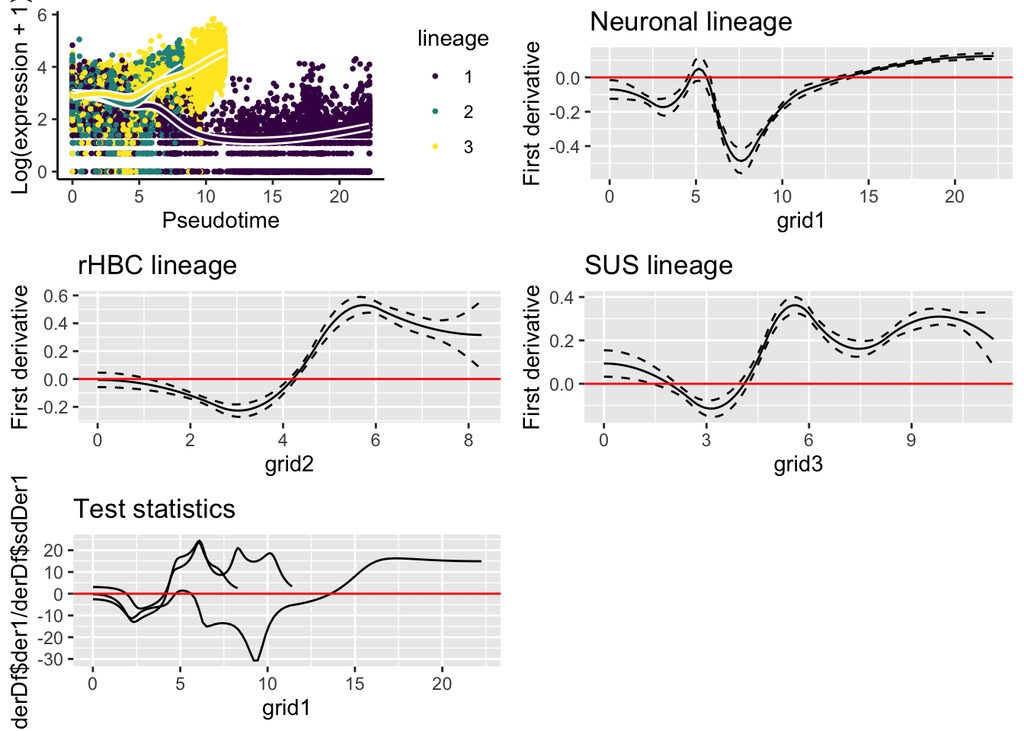

```r
grid1 <- tradeSeq:::.getPredictRangeDf(dm = dm,
                                       lineageId = 1,
                                       conditionId = NULL,
                                       nPoints = nPoints)
grid2 <- tradeSeq:::.getPredictRangeDf(dm = dm,
                                       lineageId = 2,
                                       conditionId = NULL,
                                       nPoints = nPoints)
grid3 <- tradeSeq:::.getPredictRangeDf(dm = dm,
                                       lineageId = 3,
                                       conditionId = NULL,
                                       nPoints = nPoints)
gridDf <- data.frame(grid1=grid1$t1,
                     grid2=grid2$t2,
                     grid3=grid3$t3)
plotSmoothersWithDerivatives(sce, "Junb", counts, gridDf = gridDf, derDf=derAllTF[["Junb"]])
```

## Lineage-specific ordering

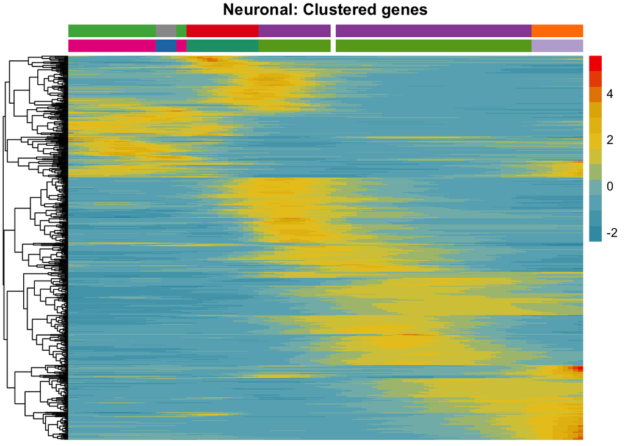

```r
# neuronal lineage
pdf("../plots/peakAnalysis_Thresholded/neuronal/orderedPeaksPlots.pdf")
neurRes <- orderPeakGenesThresh(grid=grid1, derivatives=derAllTF, tf=tf, lineage=1, sce=sce,
                            cl=clDatta, main="Neuronal", threshold = 0.1, show_rownames = FALSE)
neurPeaks <- neurRes$firstPeak
```

```r
dev.off()
```

```r
pdf("../plots/peakAnalysis_Thresholded/neuronal/orderedPeaksPlots_tallHeatmaps.pdf", width=10, height=65)
neurRes <- orderPeakGenesThresh(grid=grid1, derivatives=derAllTF, tf=tf, lineage=1, sce=sce,
                            cl=clDatta, main="Neuronal", plotHist=FALSE, plotLines=FALSE,
                            threshold = 0.1)
dev.off()
```

```r
# Sus lineage
pdf("../plots/peakAnalysis_Thresholded/sus/orderedPeaksPlots.pdf")
susRes <- orderPeakGenesThresh(grid1=grid2, derivatives=derAllTF, tf=tf, lineage=2, sce=sce,
               cl=clDatta, main="Sustentacular", threshold = 0.1)
susPeaks <- susRes$firstPeak
dev.off()
```

```r
pdf("../plots/peakAnalysis_Thresholded/sus/orderedPeaksPlots_tallHeatmaps.pdf", width=10, height=40)
susRes <- orderPeakGenesThresh(grid1=grid2, derivatives=derAllTF, tf=tf, lineage=2, sce=sce,
               cl=clDatta, main="Sustentacular", plotHist=FALSE, plotLines=FALSE, threshold = 0.1)
dev.off()
```

```r
# rHBC lineage
pdf("../plots/peakAnalysis_Thresholded/sus/orderedPeaksPlots.pdf")
rhbcRes <- orderPeakGenesThresh(grid1=grid3, derivatives=derAllTF, tf=tf, lineage=3, sce=sce,
               cl=clDatta, main="rHBC", threshold = 0.1)
rhbcPeaks <- rhbcRes$firstPeak
dev.off()
```

```r
pdf("../plots/peakAnalysis_Thresholded/rhbc/orderedPeaksPlots_tallHeatmaps.pdf", width=10, height=60)
rhbcRes <- orderPeakGenesThresh(grid1=grid3, derivatives=derAllTF, tf=tf, lineage=3, sce=sce,
               cl=clDatta, main="rHBC", plotHist=FALSE, plotLines=FALSE,
               threshold = 0.1)
dev.off()
```

```r
peakList <- list(neur=neurPeaks,
                 sus=susPeaks,
                 rhbc=rhbcPeaks)
peakResList <- list(neur=neurRes,
                    sus=susRes,
                    rhbc=rhbcRes)

saveRDS(peakList, file="../data/peakList_thresholded.rds")
saveRDS(peakResList, file="../data/peakRes_thresholded.rds")
```

### Custom plots for paper

```r
# Neuronal
png("../plots/peakAnalysis_Thresholded/neuronal/lines_neuronal.png", width=9, height=10, units="in", res=300)
neurRes <- orderPeakGenesThresh(grid=grid1, derivatives=derAllTF, tf=tf, lineage=1, sce=sce,
                            cl=clDatta, main="Neuronal", plotHist=FALSE, plotLines=TRUE,
                            plotHeatmap = FALSE, threshold = 0.1, clusteredHeatmap = FALSE,
                            show_rownames=FALSE)
dev.off()
```

```r
png("../plots/peakAnalysis_Thresholded/neuronal/cascadeHeatmap_neuronal.png", width=9, height=10, units="in", res=300)
neurRes <- orderPeakGenesThresh(grid=grid1, derivatives=derAllTF, tf=tf, lineage=1, sce=sce,
                            cl=clDatta, main="Neuronal", plotHist=FALSE, plotLines=FALSE,
                            plotHeatmap = TRUE, threshold = 0.1, clusteredHeatmap = FALSE,
                            show_rownames=FALSE)
dev.off()
```

```r
# Sus
png("../plots/peakAnalysis_Thresholded/sus/lines_sus.png", width=9, height=10, units="in", res=300)
susRes <- orderPeakGenesThresh(grid=grid2, derivatives=derAllTF, tf=tf, lineage=2, sce=sce,
                            cl=clDatta, main="Sustentacular", plotHist=FALSE, plotLines=TRUE,
                            plotHeatmap = FALSE, threshold = 0.1, clusteredHeatmap = FALSE,
                            show_rownames=FALSE)
dev.off()
```

```r
png("../plots/peakAnalysis_Thresholded/sus/cascadeHeatmap_sus.png", width=9, height=10, units="in", res=300)
susRes <- orderPeakGenesThresh(grid=grid2, derivatives=derAllTF, tf=tf, lineage=2, sce=sce,
                            cl=clDatta, main="Sustentacular", plotHist=FALSE, plotLines=FALSE,
                            plotHeatmap = TRUE, threshold = 0.1, clusteredHeatmap = FALSE,
                            show_rownames=FALSE)
dev.off()
```

```r
# HBC
png("../plots/peakAnalysis_Thresholded/rhbc/lines_rhbc.png", width=9, height=10, units="in", res=300)
rhbcRes <- orderPeakGenesThresh(grid=grid3, derivatives=derAllTF, tf=tf, lineage=3, sce=sce,
                            cl=clDatta, main="rHBC", plotHist=FALSE, plotLines=TRUE,
                            plotHeatmap = FALSE, threshold = 0.1, clusteredHeatmap = FALSE,
                            show_rownames=FALSE)
dev.off()
```

```r
png("../plots/peakAnalysis_Thresholded/rhbc/cascadeHeatmap_rhbc.png", width=9, height=10, units="in", res=300)
rhbcRes <- orderPeakGenesThresh(grid=grid3, derivatives=derAllTF, tf=tf, lineage=3, sce=sce,
                            cl=clDatta, main="rHBC", plotHist=FALSE, plotLines=FALSE,
                            plotHeatmap = TRUE, threshold = 0.1, clusteredHeatmap = FALSE,
                            show_rownames=FALSE)
dev.off()
```

## Identify shared and unique lineage TFs

We can use the results above to identify shared and unique TFs for each lineage, using a set diff. For shared TFs, we first aggregate the p-values testing whether a derivative is different from zero within the gene, using Sidak aggregation. Next, we perform FDR correction on the aggregated p-values for each lineage separately. The TFs that are significant post FDR correction in all three lineages are considered to be shared.

For TFs uniquely peaking in a lineage, we retain TFs that are significantly peaking in that lineage, and that are higher expressed in that lineage versus the other two lineages, by a fold change threshold of $1.5$ on the maximum fitted expression value.

```r
yhatAllTF <- predictSmooth(sce, gene=tf, nPoints=100, tidy=FALSE)

library(aggregation)
## shared TFs
# aggregate p-values using Sidak method for each lineage
aggPvals <- cbind(apply(neurRes$pvalThresh, 1, sidak),
                  apply(rhbcRes$pvalThresh, 1, sidak),
                  apply(susRes$pvalThresh, 1, sidak))
```

[output not shown]

[output cut: 908 more lines]

[output not shown]

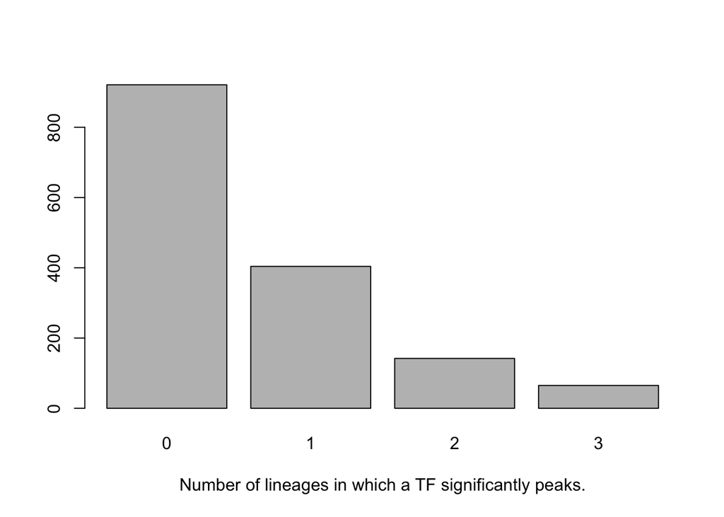

```r
# FDR correction for each lineage across all TFs
aggPvalsFDR <- apply(aggPvals,2,p.adjust,method="fdr")
barplot(table(rowSums(aggPvalsFDR <= 0.05)), xlab="Number of lineages in which a TF significantly peaks.")
```

```r
sharedTF <- rownames(aggPvalsFDR)[which(rowSums(aggPvalsFDR <= 0.05) == 3)]
length(sharedTF)
```

```
## [1] 65
```

```r
## unique TFs
getUniqueTFs <- function(peakResList, yhatAllTF, lineage, name, fcThreshold=1.5){
  # get TFs identified for that lineage
  tfLineage <- names(peakResList[[name]]$firstPeak)
  # within that set, check if expression is much higher
  linID <- ((lineage-1)*100+1):(lineage*100)
  delta <- rowMax(yhatAllTF[tfLineage,linID]) / rowMax(yhatAllTF[tfLineage,-linID])
  tfLineageDelta <- tfLineage[delta > fcThreshold]
  return(tfLineageDelta)
}
neurUniqTFs <- getUniqueTFs(peakResList, yhatAllTF, lineage=1, name="neur")
susUniqTFs <- getUniqueTFs(peakResList, yhatAllTF, lineage=2, name="sus")
rhbcUniqTFs <- getUniqueTFs(peakResList, yhatAllTF, lineage=3, name="rhbc")
length(neurUniqTFs) ; length(susUniqTFs) ; length(rhbcUniqTFs)
```

```
## [1] 352
```

```
## [1] 31
```

```
## [1] 61
```

```r
write.table(sharedTF, file="../data/sharedTF.txt", row.names=FALSE, col.names=FALSE, quote=FALSE)
write.table(neurUniqTFs, file="../data/neurUniqTf_threshold.txt", row.names=FALSE, col.names=FALSE, quote=FALSE)
write.table(susUniqTFs, file="../data/susUniqTf_threshold.txt", row.names=FALSE, col.names=FALSE, quote=FALSE)
write.table(rhbcUniqTFs, file="../data/rhbcUniqTf_threshold.txt", row.names=FALSE, col.names=FALSE, quote=FALSE)
```

## Heatmaps of shared and unique transcription factors

### TFs shared across all lineages

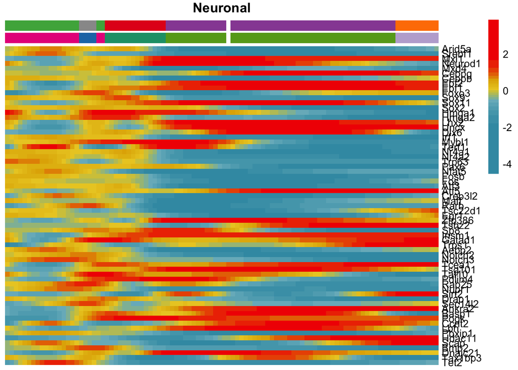

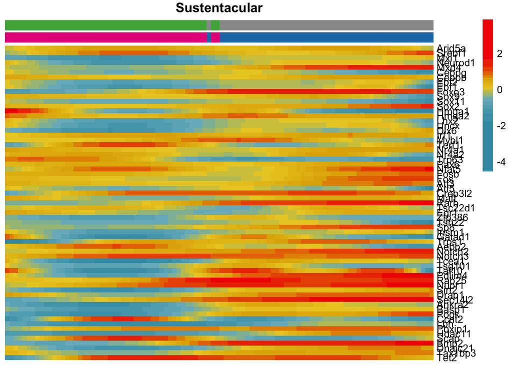

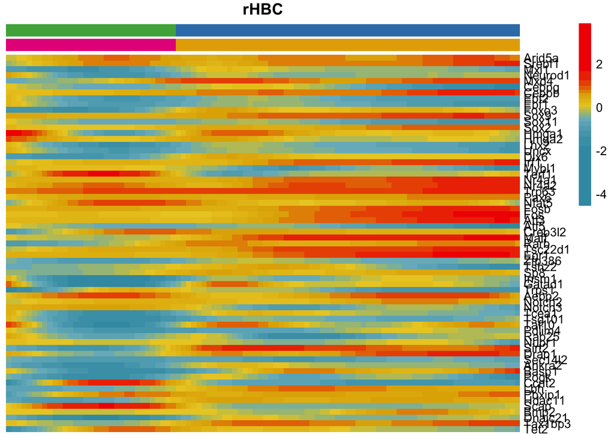

```r
### scaled across all lineages
heatmapScaledAcrossAllLineages(models=sce,
                              genes=sharedTF,
                              nPoints=100,
                              sds=sds,
                              cl=clDatta,
                              height=40,
                              outFile="../plots/peakAnalysis_Thresholded/shared/sharedTF_bigHeatmap_scaledAcrossAllLineages.pdf")
```

### Unique TFs for each lineage

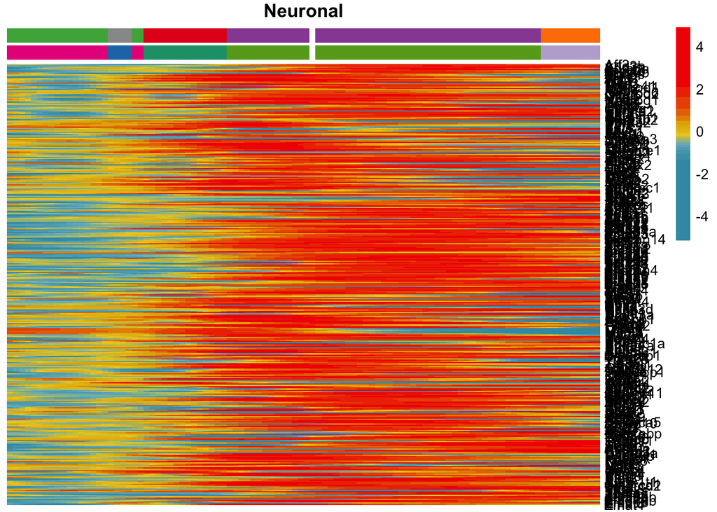

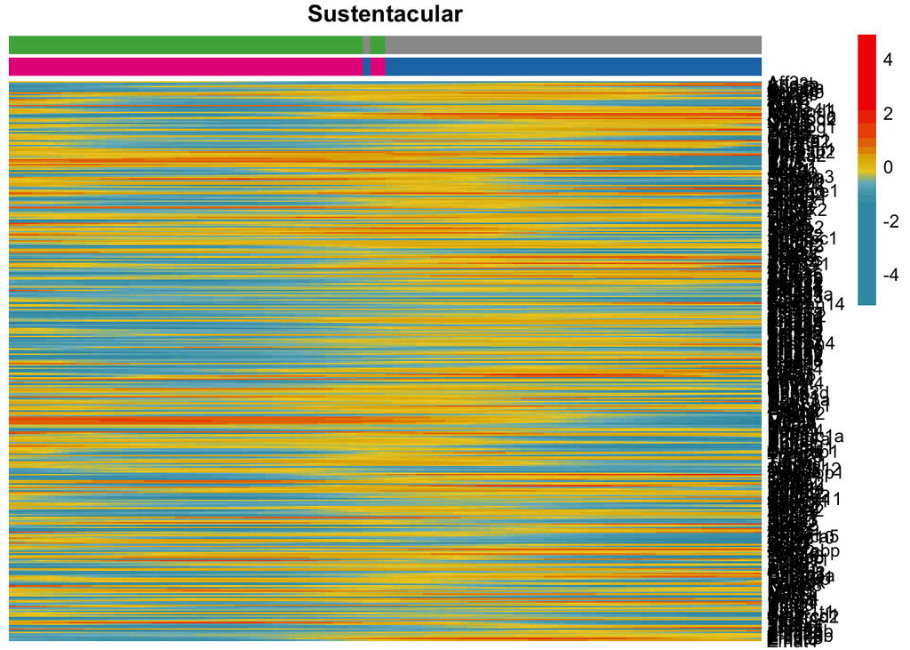

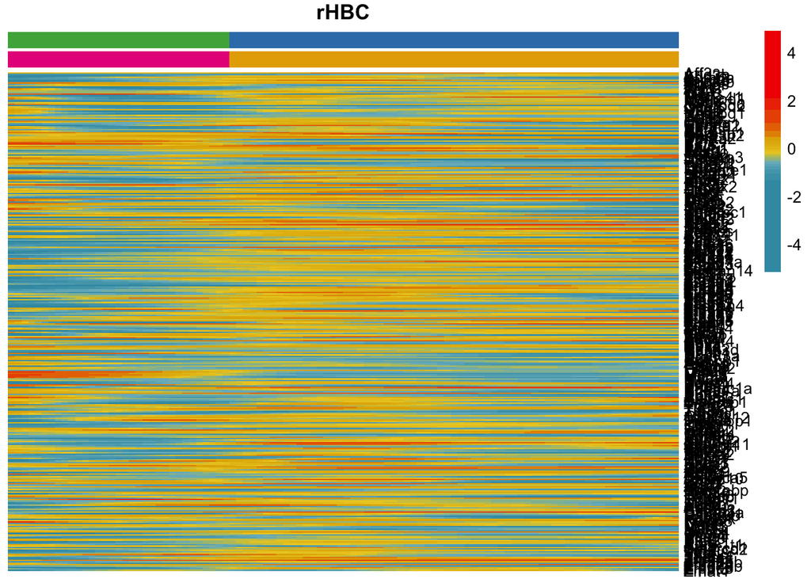

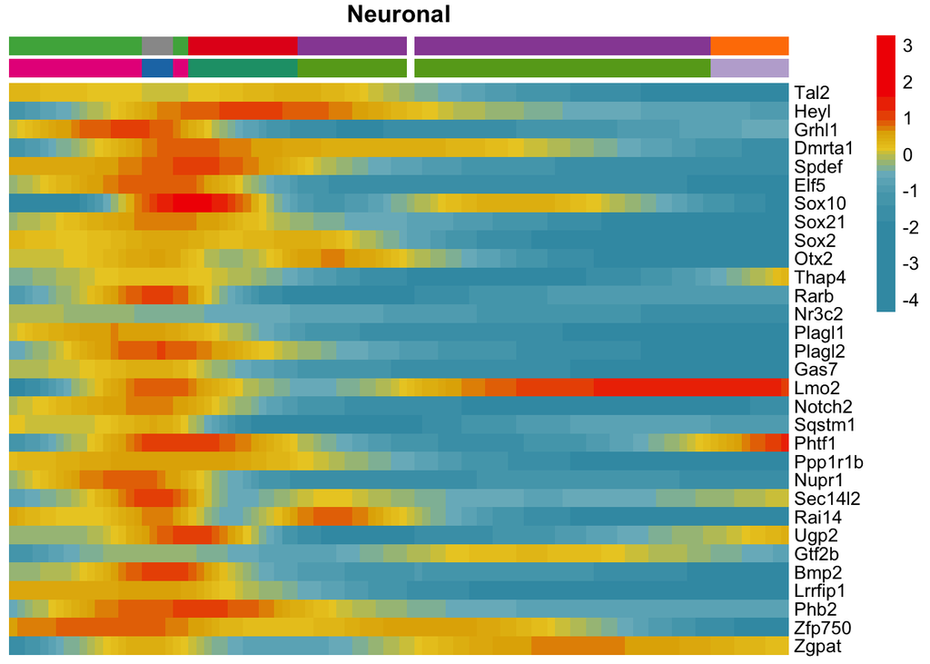

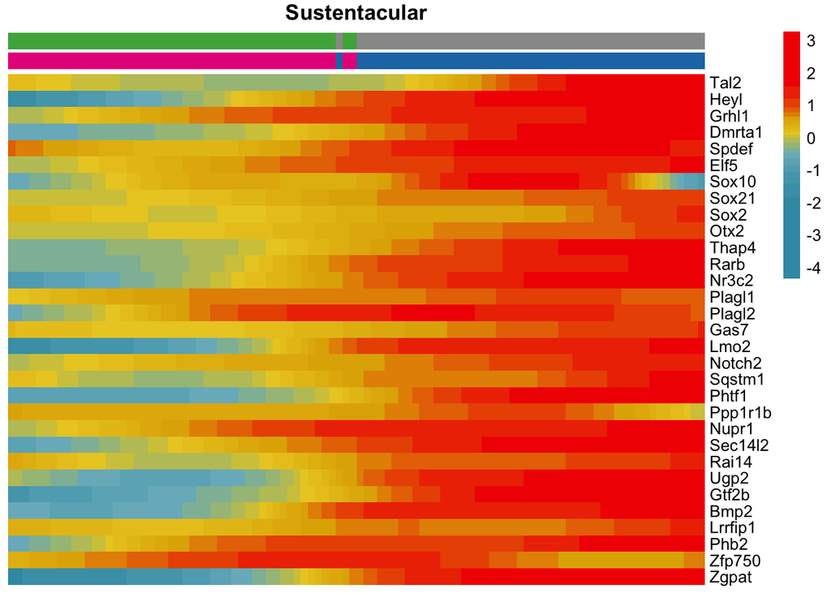

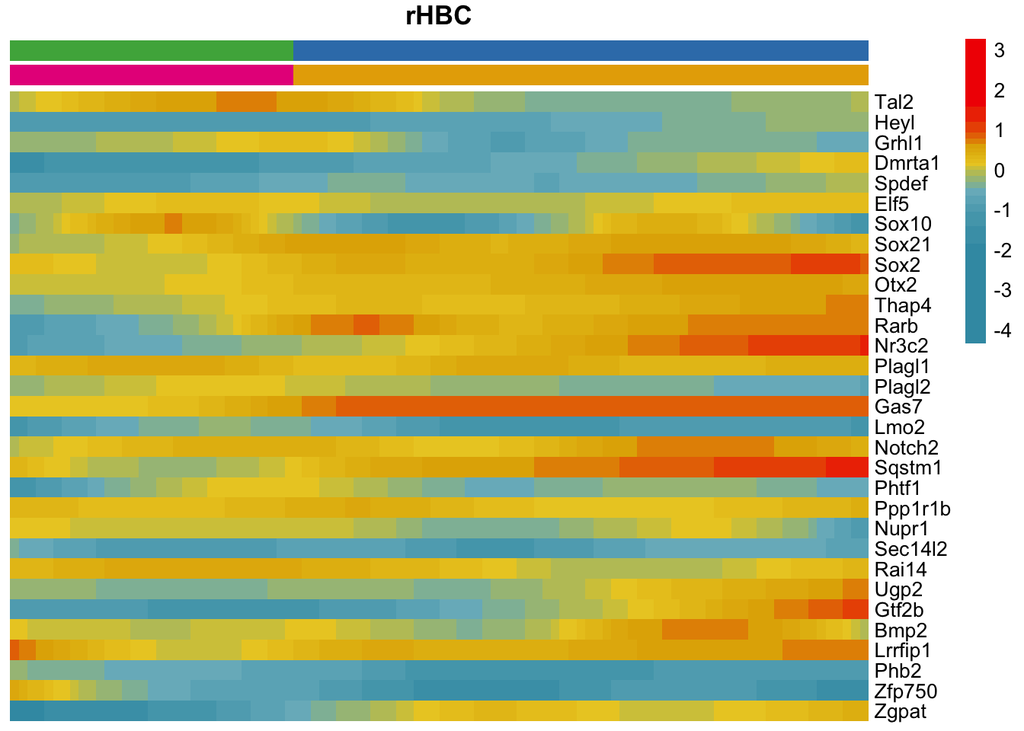

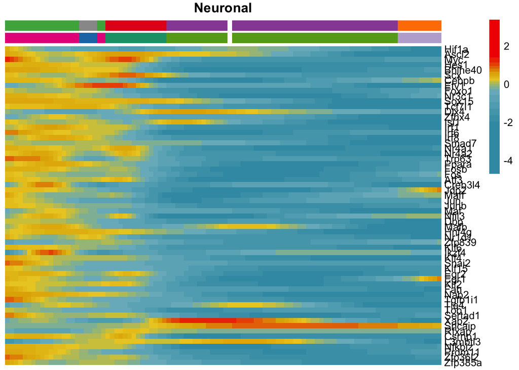

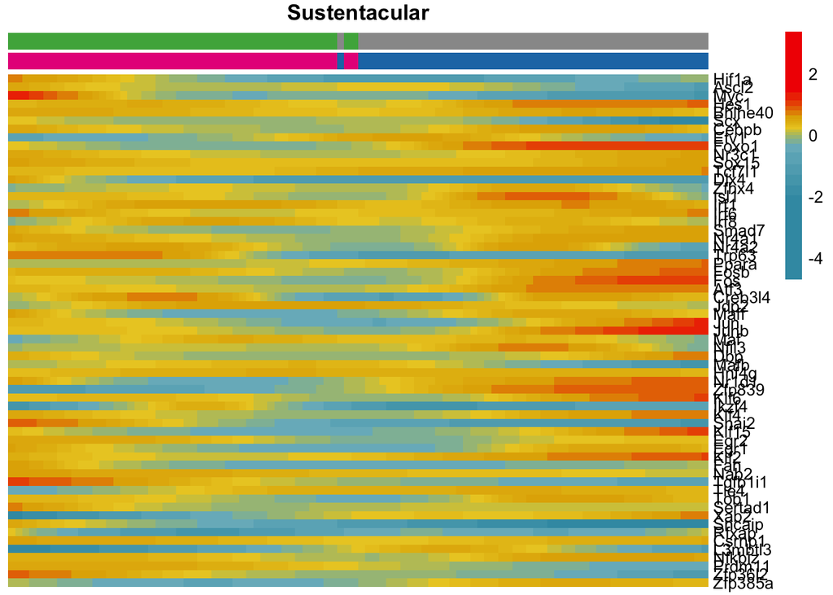

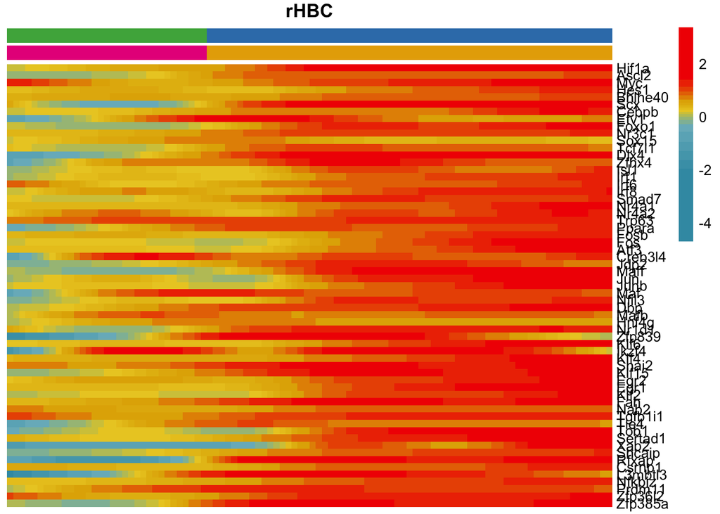

### Smoother plots of unique genes

```r
pdf("../plots/peakAnalysis_Thresholded/neuronal/smootherPlots_neurTFs.pdf")
for(ii in 1:length(neurUniqTFs)){
  print(plotSmoothers(sce, counts, sort(neurUniqTFs)[ii], pointCol = clDatta) +
          ggtitle(sort(neurUniqTFs)[ii]))
}
dev.off()
```

```r
pdf("../plots/peakAnalysis_Thresholded/sus/smootherPlots_susTFs.pdf")
for(ii in 1:length(susUniqTFs)){
   print(plotSmoothers(sce, counts, sort(susUniqTFs)[ii], pointCol = clDatta) +
          ggtitle(sort(susUniqTFs)[ii]))
}
dev.off()
```

```r
pdf("../plots/peakAnalysis_Thresholded/rhbc/smootherPlots_rhbcTFs.pdf")
for(ii in 1:length(rhbcUniqTFs)){
  print(plotSmoothers(sce, counts, sort(rhbcUniqTFs)[ii], pointCol = clDatta) +
          ggtitle(sort(rhbcUniqTFs)[ii]))
}
dev.off()
```